# Examining Seasonal Patterns of SSRI Antidepressant Use Across Scotland’s 3 Major Health Boards

Wuraola Oladunjoye

2024-11-01

## Introduction

Selective serotonin reuptake inhibitors (SSRIs) are a class of medications commonly prescribed to treat depression, anxiety, and other mental health conditions. They work by increasing the availability of serotonin, a neurotransmitter that helps regulate mood. Due to their broad application and generally favourable side effect profile, SSRIs are a key indicator of prescribing patterns linked to mental health needs within populations (Madsen et al., 2015). Mental health, however, is not static and can be influenced by various external factors, including environmental changes. Seasonal fluctuations in mood and mental health, often referred to as Seasonal Affective Disorder (SAD), are well-documented in medical literature (Lam et al., 2006). SAD is typically triggered by reduced daylight in the autumn and winter months, leading to symptoms such as low mood, anxiety, and feelings of hopelessness. While not everyone who experiences seasonal mood shifts meets the criteria for SAD, many individuals seek medical intervention, often in the form of antidepressant prescriptions (Harmatz et al., 2000).

In Scotland, where seasonal variations are pronounced—such as extended periods of darkness in winter and unpredictable weather—these environmental factors may exacerbate mental health challenges. This could contribute to increased SSRI prescriptions during certain times of the year. Previous studies have shown that seasonal trends in antidepressant prescribing are influenced not only by environmental factors but also by societal pressures and healthcare access(Jack et al., 2023).

This report examines the seasonal trends in SSRI prescriptions across Scotland’s three major health boards, which represent the largest and primarily urban populations. Using the Public Health Scotland prescribing data, available here: https://www.opendata.nhs.scot/dataset/prescriptions-in-the-community

The analysis aims to identify whether SSRI prescriptions show distinct seasonal patterns. While this analysis focuses solely on SSRI prescription data and does not include specific conditions for which they are prescribed. Any suggested causes for these trends are speculative, as the data is limited to prescription counts rather than diagnoses or underlying factors.

By presenting these patterns, this report aims to contribute to a better understanding of SSRI use across Scotland’s major health boards and highlight areas for further investigation into the broader factors that may drive these trends.

Load Necessary Libraries

```r
#load necessary libraries
library(tidyverse)
library(janitor)
library(gt)
library(here)
```

```r
# Function to process prescription data from multiple CSV files
process_prescription_data <- function(file_paths, health_boards) {
  # Step 1: Load and combine the files
  processed_data <- map_dfr(file_paths, ~ {
    message("Processing file: ", .x)  # Debugging log
    # Read the file, select relevant columns and filter relevant rows
    read_csv(.x, col_types = cols()) %>%
      select(HBT2014, BNFItemDescription, PaidQuantity, PaidDateMonth) %>%
      filter(str_detect(BNFItemDescription, "^(SERTRALINE|PAROXETINE|FLUOXETINE|CITALOPRAM|ESCITALOPRAM)") &
               HBT2014 %in% health_boards)})
  # Step 2: Cleaning and transforming the data by using mutate
  full_prescribed_data <- processed_data %>%
    mutate( # Retaining the PaidDateMonth in YYYYMMDD format
      PaidDateMonth = sprintf("%06d",    as.numeric(PaidDateMonth)), PaidDateMonth = paste0(PaidDateMonth, "01"),
      # Appending day to create YYYYMMDD format as string
      PaidDate = as.Date(PaidDateMonth, format = "%Y%m%d"),  # Convert to Date object
      Year = format(PaidDate, "%Y"),  # Extract Year as string
      # Create Season column based on PaidDate
      Season = case_when(
        format(PaidDate, "%m") %in% c("12", "01", "02") ~ "Winter",
        format(PaidDate, "%m") %in% c("03", "04", "05") ~ "Spring",
        format(PaidDate, "%m") %in% c("06", "07", "08") ~ "Summer",
        format(PaidDate, "%m") %in% c("09", "10", "11") ~ "Autumn",
        TRUE ~ "Unknown") ) %>%
    # Recode health boards to be more readable
    mutate(HealthBoard = recode(HBT2014,
      "S08000032" = "Lanarkshire",
      "S08000031" = "Greater Glasgow & Clyde",
      "S08000024" = "Lothian",
      "S08000023" = "Lanarkshire",
      "S08000021" = "Greater Glasgow & Clyde")) %>%
    select(-HBT2014)  # Drop the original HBT2014 column
    return(full_prescribed_data)}
# 2019 prescription data
pitc_list <- list.files(path = "C:/Users/wurao/OneDrive/Documents/data_science/B205492/docs",
         pattern = "pitc2019.*\\.csv$", full.names =TRUE)
health_boards <- c("S08000032", "S08000031", "S08000024")
# Process the data using the updated function
processed_data_2019 <- process_prescription_data(pitc_list, health_boards)
# Summarize total prescriptions by Health Board, Season, Year
seasonal_data <- processed_data_2019 %>%
  group_by(HealthBoard, Season, Year, ) %>%
  summarise( "Total prescriptions" = sum(PaidQuantity, na.rm = TRUE), .groups = 'drop')
```

## 2019 Trend

Figure 1

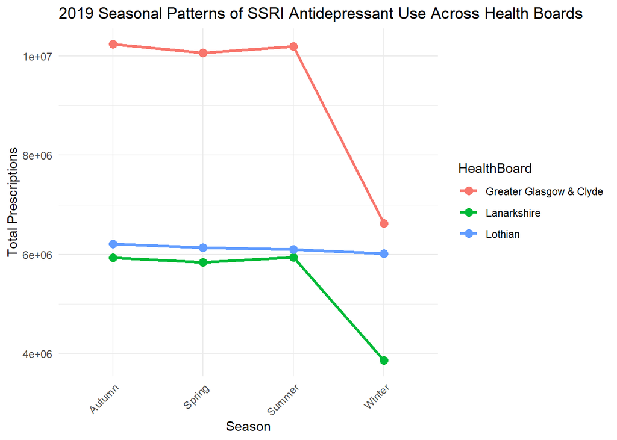

```r
seasonal_data <- seasonal_data %>%
 mutate(HealthBoard = str_trim(HealthBoard)) #to remove any leading or trailing whitespace characters from the HealthBoard column in the dataset
seasonal_plot <- seasonal_data %>%
  ggplot(aes(x = Season, y = `Total prescriptions`, group = HealthBoard, color = HealthBoard)) +
  geom_line(linewidth = 1.2) +  # Line plot with specified line width
  geom_point(size = 3) +  # Add points to the plot
  labs(title = "2019 Seasonal Patterns of SSRI Antidepressant Use Across Health Boards", x = "Season",y = "Total Prescriptions" ) +
  theme_minimal() +  theme(axis.text.x = element_text(angle = 45, hjust = 1))  # Rotate x-axis labels
# Print the plot
print(seasonal_plot)
```

## 2016-2018 Trend

```r
# Step 1: Listing Relevant CSV Files
pitc_list <- list.files(path = here("docs"),
  pattern = "pitc(2016|2017|2018)(jan|feb|mar|apr|may|jun|jul|aug|sep|oct|nov|dec)\\.csv$",
  full.names = TRUE)

if (length(pitc_list) == 0) { stop("No matching files found. Check the file names or pattern.")}
# Step 2: Apply the function to process the files
health_boards <- c("S08000023", "S08000021", "S08000024")  # Customize this as needed
three_years_data <- process_prescription_data(pitc_list, health_boards)
```

Figure 2

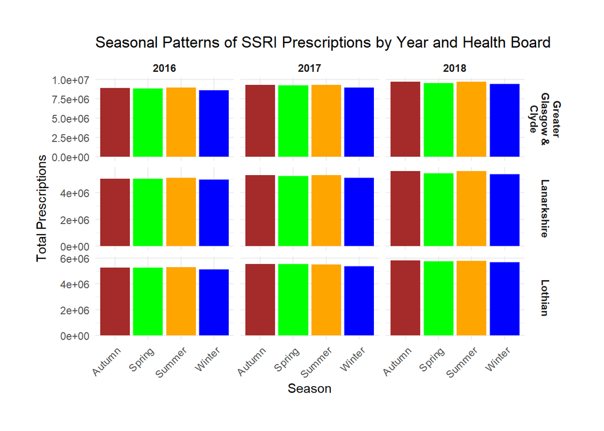

```r
# Summarize Data
Bar_prescribed_data <- three_years_data %>%
  group_by(Season, Year, HealthBoard,) %>%
  summarize(`Total prescriptions` = sum(PaidQuantity, na.rm = TRUE),       .groups = "drop")
# Create Bar Plot
ggplot(Bar_prescribed_data, aes(x = Season, y = `Total prescriptions`, fill = Season)) +
  geom_bar(stat = "identity", position = position_dodge(width = 5), width = 0.9) +  # Adjusting spacing and bar width
  facet_grid(
    rows = vars(HealthBoard),  # Using rows for HealthBoard
    cols = vars(Year),
    scales = "free_y",  # Adjust y-scales independently
    labeller = label_wrap_gen(width = 15)  # Wrap long facet labels
  ) +
  labs(
    title = "Seasonal Patterns of SSRI Prescriptions by Year and Health Board",
    x = "Season",
    y = "Total Prescriptions"
  ) +
  theme_minimal() +
  theme(
    axis.text.x = element_text(angle = 45, hjust = 1),   # Rotating x-axis labels
    strip.text = element_text(face = "bold"),
    plot.margin = margin(30, 30, 30, 30),  # Add larger margins to avoid clipping
    legend.position = "none"
  ) +
  scale_fill_manual(values = c("Winter" = "blue", "Spring" = "green", "Summer" = "orange", "Autumn" = "brown")) +
  coord_cartesian(clip = "off")  # Prevent clipping of text outside plot area
```

Figure 3

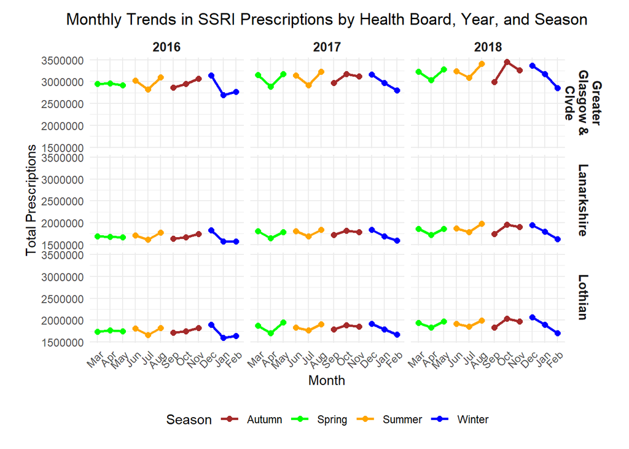

```r
# Summarize the data and prepare for plotting
monthly_data <- three_years_data %>%
  group_by(Year, HealthBoard, PaidDateMonth,Season) %>%  # Ensure columns are correctly grouped
  summarize(`Total prescriptions` = sum(PaidQuantity, na.rm = TRUE), .groups = "drop") %>%
  # Create a Month_Factor to order months starting with March
  mutate(Month_Factor = factor(format(as.Date(PaidDateMonth, format = "%Y%m%d"), "%b"),  # Extract abbreviated month name from the date
    levels = c("Mar", "Apr", "May", "Jun", "Jul", "Aug", "Sep", "Oct", "Nov", "Dec", "Jan", "Feb")))
# Plot the monthly trends with seasons
ggplot(monthly_data, aes(x = Month_Factor, y = `Total prescriptions`, group = Season, color = Season)) +
  geom_line(size = 1) +  # Line plot with color for Season
  geom_point(size = 2) +  # Adding points for better visibility
  facet_grid(HealthBoard ~ Year, labeller = labeller(HealthBoard = label_wrap_gen(15))  # Wrap labels for HealthBoard
  ) + labs( title = "Monthly Trends in SSRI Prescriptions by Health Board, Year, and Season", x = "Month", y = "Total Prescriptions",color = "Season" ) + scale_color_manual(values = c("Winter" = "blue", "Spring" = "green","Summer" = "orange", "Autumn" = "brown")) +  # Custom colors for seasons
  theme_minimal() + theme( axis.text.x = element_text(angle = 45, hjust = 1),  # Rotate x-axis labels
    strip.text = element_text(face = "bold", size = 10),
    legend.position = "bottom",  # Legend below the plot
    plot.title = element_text(hjust = 0.5),  # Center the plot title
    strip.text.y = element_text(margin = margin(r = 10)),  # Add margin to HealthBoard labels
    plot.margin = margin(t = 10, r = 10, b = 10, l = 20)  # Increase overall plot margins
  )
```

## Table

```r
# Combine 2016-2018 and 2019 datasets
combined_prescribed_data <- bind_rows(Bar_prescribed_data, seasonal_data)
# Create the gt table
gt_table <- combined_prescribed_data %>%
  arrange(Year, HealthBoard, Season) %>%
  gt(rowname_col = "Season", groupname_col = "Year") %>%
  tab_header(
    title = md("**Seasonal Trends in SSRI Prescriptions Across Major Scottish Health Boards (2016-2019)**"),
    subtitle = "Overview of Seasonal Prescription Totals by Health Board" )%>%
  cols_label(
    Year = "Year",
    HealthBoard = "Health Board",
    Season = "Season",
   `Total prescriptions` = "Total Prescriptions") %>%
  fmt_number(columns = `Total prescriptions`,decimals = 0  # No decimals for prescription counts
  ) %>%
  tab_style(style = cell_text(weight = "bold"),locations = cells_row_groups(groups = TRUE)  # Bold year group labels
  ) %>%
  tab_options(
    row_group.as_column = TRUE,
    table.font.size = 14,  # Larger font size for readability
    data_row.padding = px(10),
    column_labels.font.size = 16,  # Bigger column headers
    heading.border.bottom.color = "gray85",
    heading.border.bottom.width = px(2)) %>%
  tab_spanner(
    label = "Health Board and Season",
    columns = c("HealthBoard", "Season")) %>%
  tab_style(
    style = cell_fill(color = "lightgray"),
    locations = cells_body(rows = seq(1, nrow(combined_prescribed_data), by = 2))  # Even rows
    ) %>%
  tab_style( style = cell_fill(color = "lightblue"),
    locations = cells_body(rows = seq(2, nrow(combined_prescribed_data), by = 2))  # Odd rows
  ) %>%
  tab_style(style = cell_text(align = "center"),
    locations = cells_body()  # Center align body cells
  ) %>%
  tab_style(style = cell_text(align = "center"),
    locations = cells_column_labels()  # Center align column headers
  ) %>%
  tab_style(style = cell_text(weight = "bold", color = "darkblue"),
    locations = cells_column_labels(columns = c("Year", "HealthBoard"))) %>%
  tab_style(style = cell_text(weight = "normal", color = "black"),
    locations = cells_body(columns = c("Year", "HealthBoard", "Season"))) %>%
  tab_options(table.width = pct(100),  # Set the table to take up 100% of the width
    table.align = "center"   # Align the table to the center
  )

# Display the formatted table
gt_table
```

**Seasonal Trends in SSRI Prescriptions Across Major Scottish Health Boards (2016-2019)**

Overview of Seasonal Prescription Totals by Health Board

|  |  | Health Board and Season Health Board | Total Prescriptions |  |
| --- | --- | --- | --- | --- |
| 2016 | Autumn | Greater Glasgow & Clyde |  | 8,884,463 |
|  | Spring | Greater Glasgow & Clyde | 8,821,739 |  |
|  | Summer | Greater Glasgow & Clyde | 8,940,972 |  |
|  | Winter | Greater Glasgow & Clyde | 8,594,210 |  |
|  | Autumn | Lanarkshire | 5,052,455 |  |
|  | Spring | Lanarkshire | 5,042,549 |  |
|  | Summer | Lanarkshire | 5,104,842 |  |
|  | Winter | Lanarkshire | 4,966,728 |  |
|  | Autumn | Lothian | 5,280,164 |  |
|  | Spring | Lothian | 5,249,669 |  |
|  | Summer | Lothian | 5,296,597 |  |
|  | Winter | Lothian | 5,121,263 |  |
| 2017 | Autumn | Greater Glasgow & Clyde | 9,272,569 |  |
|  | Spring | Greater Glasgow & Clyde | 9,212,639 |  |
|  | Summer | Greater Glasgow & Clyde | 9,285,008 |  |
|  | Winter | Greater Glasgow & Clyde | 8,941,147 |  |
|  | Autumn | Lanarkshire | 5,317,885 |  |
|  | Spring | Lanarkshire | 5,242,997 |  |
|  | Summer | Lanarkshire | 5,330,759 |  |
|  | Winter | Lanarkshire | 5,125,656 |  |
|  | Autumn | Lothian | 5,529,307 |  |
|  | Spring | Lothian | 5,528,153 |  |
|  | Summer | Lothian | 5,501,288 |  |
|  | Winter | Lothian | 5,382,146 |  |
| 2018 | Autumn | Greater Glasgow & Clyde | 9,706,148 |  |
|  | Spring | Greater Glasgow & Clyde | 9,537,012 |  |
|  | Summer | Greater Glasgow & Clyde | 9,729,360 |  |
|  | Winter | Greater Glasgow & Clyde | 9,391,876 |  |
|  | Autumn | Lanarkshire | 5,612,085 |  |
|  | Spring | Lanarkshire | 5,444,050 |  |
|  | Summer | Lanarkshire | 5,629,655 |  |
|  | Winter | Lanarkshire | 5,376,101 |  |
|  | Autumn | Lothian | 5,832,617 |  |
|  | Spring | Lothian | 5,755,843 |  |
|  | Summer | Lothian | 5,768,094 |  |
|  | Winter | Lothian | 5,670,963 |  |
| 2019 | Autumn | Greater Glasgow & Clyde | 10,234,142 |  |
|  | Spring | Greater Glasgow & Clyde | 10,062,044 |  |
|  | Summer | Greater Glasgow & Clyde | 10,189,077 |  |
|  | Winter | Greater Glasgow & Clyde | 6,630,138 |  |
|  | Autumn | Lanarkshire | 5,931,818 |  |
|  | Spring | Lanarkshire | 5,840,297 |  |
|  | Summer | Lanarkshire | 5,946,353 |  |
|  | Winter | Lanarkshire | 3,863,237 |  |
|  | Autumn | Lothian | 6,210,689 |  |
|  | Spring | Lothian | 6,141,095 |  |
|  | Summer | Lothian | 6,104,339 |  |
|  | Winter | Lothian | 6,017,089 |  |